# Lane-Emden equation Solver by W4

- Differential equation which expresses the stellar structure
- It is obtained from the Euler equation(fluid )

# Package Inclusion

- Sympy :: To define the set of nonlinear equations
- Numpy :: For iterative solver
- Scipy :: To use Linear solver
- Matplotlib :: For Basin figure

```python
import sympy as sy;
import numpy as np;
from numpy import cos,sin,pi;
from scipy import linalg;
import matplotlib.pyplot as plt;
```

# Parameter Setup

For the W4 method, we define

- dim : dimension of system (It determines the resolution)
- dtau : $\Delta\tau$ for evolution
- errmax : Criterion of error to stop iteration
- itermax : Maximum iteration.

```python
dim0=20;
dim1=10;
```

```python
dtau=1.0;
errmax = pow(10,-6);
itermax = pow(10,3);
```

```python
### Variables
### x[1], x[2], x[3], ... , x[dim]
###
x0 = []
for i in range(0,dim0):
    vname = 'x[' + str(i) +']';
    x0.append(sy.symbols(vname));

x1 = []
for i in range(0,dim1):
    vname = 'x[' + str(i) +']';
    x1.append(sy.symbols(vname));
```

# Definition of Source in the Sympy style

- **F**(**x**) : System of nonlinear equations
- |**F**(**x**)| : Absolute components
- J : Jacobian matrix $\partial$ **F** / $\partial$ **x**

# $\frac{d^2\theta}{d\xi^2}+\frac{2}{\xi}\frac{d\theta}{d\xi}+r_{*}^2\theta^{n}=0$

```python
### Source
### f[0], f[1], f[2], ... , f[dim-1]
n = 1;
f0 = [];

### Coordinate xi
dx0 = 1.0/dim0;
xi0 = [];
for i in range(dim0+1):
    xi0.append( dx0*i );


### Source for Eigenvalue x[0]
f0.append( 6*(x0[1] -1)/dx0**2  +x0[0] );

### Source for x[1] (theta(dx)) with boundary condition theta(0)=1
f0.append( (x0[2] -2*x0[1] +1)/dx0**2 +(x0[2]-1)/xi0[1]/dx0 +x0[1]**n*x0[0] );

for i in range(2,dim0-1):
    f0.append( (x0[i+1] -2*x0[i] +x0[i-1])/dx0**2 +(x0[i+1]-x0[i-1])/xi0[i]/dx0 +x0[i]**n*x0[0] );

### Source for x[dim-1] (theta(1-dx)) with boundary condition theta(1)=0
f0.append( (0 -2*x0[dim0-1] +x0[dim0-2])/dx0**2 +(0-x0[dim0-2])/xi0[dim0-1]/dx0 +x0[dim0-1]**n*x0[0] );

#f

#f[0] = (6*(x[1] -1)/dx**2  +x[0]);
tmp = f0[0];
#norm = 0.0;
for i in range(1,dim0):
    tmp = tmp +f0[i]*x0[i];
#    norm = norm +x[i]**n*x[i];

f0[0] = tmp;
```

```python
### Source
### f[0], f[1], f[2], ... , f[dim-1]
n = 1;
f1 = [];

### Coordinate xi
dx1 = 1.0/dim1;
xi1 = [];
for i in range(dim1+1):
    xi1.append( dx1*i );


### Source for Eigenvalue x[0]
f1.append( 6*(x1[1] -1)/dx1**2  +x1[0] );

### Source for x[1] (theta(dx)) with boundary condition theta(0)=1
f1.append( (x1[2] -2*x1[1] +1)/dx1**2 +(x1[2]-1)/xi1[1]/dx1 +x1[1]**n*x1[0] );

for i in range(2,dim1-1):
    f1.append( (x1[i+1] -2*x1[i] +x1[i-1])/dx1**2 +(x1[i+1]-x1[i-1])/xi1[i]/dx1 +x1[i]**n*x1[0] );

### Source for x[dim-1] (theta(1-dx)) with boundary condition theta(1)=0
f1.append( (0 -2*x1[dim1-1] +x1[dim1-2])/dx1**2 +(0-x1[dim1-2])/xi1[dim1-1]/dx1 +x1[dim1-1]**n*x1[0] );

#f

#f[0] = (6*(x[1] -1)/dx**2  +x[0]);
tmp = f1[0];
#norm = 0.0;
for i in range(1,dim1):
    tmp = tmp +f1[i]*x1[i];
#    norm = norm +x[i]**n*x[i];

f1[0] = tmp;
```

```python
# input source
def calc_source(dim,x,f):

### Summation of absolute values of all terms in each equation
###  to compare the error with the typical value of each equation
    fa = [];
    for j in range(dim):
        tmp = 0;
        for i in range(len(f[j].args)):
            tmp = tmp + abs(f[j].args[i]);
        fa.append(tmp);

### Definition of variables, sources, absolute sources(x, F, |F|) as vector
    v = sy.Matrix([x]).transpose();
    F = sy.Matrix([f]).transpose();
    Fa = sy.Matrix([fa]).transpose();

### Analytic calculation of Jacobian(dim x dim Matrix)
    J = sy.Matrix();
    for i in range(dim):
        J = J.col_insert(i,F.diff(x[i]));

### From Sympy to Numpy
    arg = v.transpose();
    vn = sy.lambdify(arg, v, "numpy")
    Fn = sy.lambdify(arg, F, "numpy")
    Fan = sy.lambdify(arg, Fa, "numpy")
    Jacn = sy.lambdify(arg, J, "numpy")

    return vn,Fn,Fan,Jacn;
```

```python
vn0, Fn0, Fan0, Jacn0 = calc_source(dim0,x0,f0);
vn1, Fn1, Fan1, Jacn1 = calc_source(dim1,x1,f1);
```

# Definition :: W4ID method

```python
### Analysis by the W4 method with the LH decomposition
def w4MG0(dim,v,F,Fa,J,ini,dt,itermax,errmax):

### Initialization for x and p as v0 and p0
    p0 = np.zeros(dim);
    v0 = v(*ini).transpose()[0];

#    evot = [];
#    evot = np.append(evot,0);
#    evox = np.array([v0]).reshape(1,dim);
#    evop = np.array([p0]).reshape(1,dim);
#    evolam = [];
    J0=J(*v0);

    YJX = J0;
    for i in range(dim):
        tmp = 0.0;
        for k in range(dim):
            tmp = tmp +J0[k][i]**2;

        for k in range(dim):
            YJX[i][k] = YJX[i][k]*J0[i][i]/tmp;

#    lam = linalg.eigvals(YJX)
#    lam = np.sort(lam)[::-1]

### Main Iteration Loop
    for i in range(itermax):
        J0=J(*v0);
        F0=F(*v0).transpose()[0].transpose();
        Fa0=Fa(*v0).transpose()[0].transpose();

### Criterion to stop the iteration
### Evaluation of Source F
        err = 0.0;
        for k in range(dim):
            err = max(err,abs(F0[k]/Fa0[k]));

        if err < errmax:
            break;

### Incomplete Diagonal Matrix (W4ID method)
        srcx0 = np.zeros(dim);
        srcp0 = np.zeros(dim);
        for j in range(dim):
            tmp = 0.0;
            for k in range(dim):
                tmp = tmp +J0[k][j]**2;

            srcp0[j] = F0[j]/tmp;
            srcx0[j] = p0[j]*J0[j][j];

        srcp = -2*p0 -srcp0
        srcx = srcx0

        v0 = v0 +srcx*dt;
        p0 = p0 +srcp*dt;
#        evot = np.append(evot,i);
#        evox = np.append(evox,np.array([v0]),axis=0);
#        evop = np.append(evop,np.array([p0]),axis=0);

    return v0, i+1, err, v0, F0#, lam, evot, evox, evop
```

```python
### Initial guess
vini0 = np.array([]);
vini0 = np.append(vini0, 1.);
for i in range(1,dim0):
    vini0 = np.append(vini0, (1.0 -dx0*i));

### Nonlinear Solver by the W4 method
vans0, iter0, err0, vv, FF = w4MG0(dim0,vn0,Fn0,Fan0,Jacn0,vini0,dtau,itermax,errmax);
#vans, iter, err, lam, t, xr, pr = w4analysis(vn,Fn,Fan,Jacn,vini,dtau,itermax,errmax);

vans0, iter0, err0, v0, F0 = w4MG0(dim0,vn0,Fn0,Fan0,Jacn0,vv,dtau,itermax,errmax);

### Basic information
print("Dimension : ",dim0);
#print("Initial Condition number : ",lam[1]);
print("Iteration : ",iter0,", error : ", err0);
if iter0 < itermax-1:
    print("< Solved. >");
else:
    print("< Failed. >");
```

[output not shown]

```python
### Analysis by the W4 method with the LH decomposition
def w4IDanalysis(dim,v,F,Fa,J,ini,dt,itermax,errmax):

### Initialization for x and p as v0 and p0
    p0 = np.zeros(dim);
    v0 = v(*ini).transpose()[0];

    evot = [];
    evot = np.append(evot,0);
    evox = np.array([v0]).reshape(1,dim);
    evop = np.array([p0]).reshape(1,dim);
    evolam = [];
    J0=J(*v0);

    YJX = J0;
    for i in range(dim):
        tmp = 0.0;
        for k in range(dim):
            tmp = tmp +J0[k][i]**2;

        for k in range(dim):
            YJX[i][k] = YJX[i][k]*J0[i][i]/tmp;

    lam = linalg.eigvals(YJX)
    lam = np.sort(lam)[::-1]

### Main Iteration Loop
    for i in range(itermax):
        J0=J(*v0);
        F0=F(*v0).transpose()[0].transpose();
        Fa0=Fa(*v0).transpose()[0].transpose();

### Criterion to stop the iteration
### Evaluation of Source F
        err = 0.0;
        for k in range(dim):
            err = max(err,abs(F0[k]/Fa0[k]));

        if err < errmax:
            break;

### Incomplete Diagonal Matrix (W4ID method)
        srcx0 = np.zeros(dim);
        srcp0 = np.zeros(dim);
        for j in range(dim):
            tmp = 0.0;
            for k in range(dim):
                tmp = tmp +J0[k][j]**2;

            srcp0[j] = F0[j]/tmp;
            srcx0[j] = p0[j]*J0[j][j];

        srcp = -2*p0 -srcp0
        srcx = srcx0

        v0 = v0 +srcx*dt;
        p0 = p0 +srcp*dt;
        evot = np.append(evot,i);
        evox = np.append(evox,np.array([v0]),axis=0);
        evop = np.append(evop,np.array([p0]),axis=0);

    return v0, i+1, err, lam, evot, evox, evop
```

# Definition :: W4LH method

```python
### Analysis by the W4 method with the LH decomposition
def w4analysis(v,F,Fa,J,ini,dt,itermax,errmax):

### Initialization for x and p as v0 and p0
    p0 = np.zeros(dim);
    v0 = v(*ini).transpose()[0];

    evot = [];
    evot = np.append(evot,0);
    evox = np.array([v0]).reshape(1,dim);
    evop = np.array([p0]).reshape(1,dim);
    evolam = [];
    J0=J(*v0);
    lam = linalg.eigvals(J0)
    lmin=abs(lam[0]);
    lmax=abs(lam[0]);
    for d in range(dim):
        if lmin > abs(lam[d]):
            lmin = abs(lam[d]);
        if lmax < abs(lam[d]):
            lmax = abs(lam[d]);

    evolam = np.append(evolam,lmax/lmin);


### Main Iteration Loop
    for i in range(itermax):
        J0=J(*v0);
        F0=F(*v0).transpose()[0].transpose();
        Fa0=Fa(*v0).transpose()[0].transpose();

### Criterion to stop the iteration
### Evaluation of Source F
        err = 0.0;
        for k in range(dim):
            err = max(err,abs(F0[k]/Fa0[k]));

        if err < errmax:
            break;

### Decomposition of Jacobian into L and H
        Q, R = linalg.qr(J0.transpose());
        srcp = -2*p0 -linalg.solve(R.transpose(),F0);
        srcx = Q.dot(p0);
#        srcx = Q.transpose().dot(p0);
        v0 = v0 +srcx*dt;
        p0 = p0 +srcp*dt;
        evot = np.append(evot,i);
        evox = np.append(evox,np.array([v0]),axis=0);
        evop = np.append(evop,np.array([p0]),axis=0);

        lam = linalg.eigvals(J0)
        lmin=abs(lam[0]);
        lmax=abs(lam[0]);
        for d in range(dim):
            if lmin > abs(lam[d]):
                lmin = abs(lam[d]);
            if lmax < abs(lam[d]):
                lmax = abs(lam[d]);

        evolam = np.append(evolam,lmax/lmin);

    return v0, i, err, evolam, evot, evox, evop
```

```python
### Initial guess
vini0 = np.array([]);
vini0 = np.append(vini0, 1.);
for i in range(1,dim0):
    vini0 = np.append(vini0, (1.0 -dx0*i));

### Nonlinear Solver by the W4 method
vans0, iter0, err0, lam0, t0, xr0, pr0 = w4IDanalysis(dim0,vn0,Fn0,Fan0,Jacn0,vini0,dtau,itermax,errmax);
#vans, iter, err, lam, t, xr, pr = w4analysis(vn,Fn,Fan,Jacn,vini,dtau,itermax,errmax);

### Basic information
print("Dimension : ",dim0);
#print("Initial Condition number : ",lam[1]);
print("Iteration : ",iter0,", error : ", err0);
if iter0 < itermax-1:
    print("< Solved. >");
else:
    print("< Failed. >");
```

```
Dimension :  20
Iteration :  491 , error :  9.895970878185245e-07
< Solved. >
```

```python
### Initial guess
vini1 = np.array([]);
vini1 = np.append(vini1, 1.);
for i in range(1,dim1):
    vini1 = np.append(vini1, (1.0 -dx1*i));

### Nonlinear Solver by the W4 method
vans1, iter1, err1, lam1, t1, xr1, pr1 = w4IDanalysis(dim1,vn1,Fn1,Fan1,Jacn1,vini1,dtau,itermax,errmax);
#vans, iter, err, lam, t, xr, pr = w4analysis(vn,Fn,Fan,Jacn,vini,dtau,itermax,errmax);

### Basic information
print("Dimension : ",dim1);
#print("Initial Condition number : ",lam[1]);
print("Iteration : ",iter1,", error : ", err1);
if iter1 < itermax-1:
    print("< Solved. >");
else:
    print("< Failed. >");
```

```
Dimension :  10
Iteration :  195 , error :  9.817945571778084e-07
< Solved. >
```

```python
#xr[iter]
lam1 = abs(lam1-1)
lam0 = abs(lam0-1)

lam1 = np.sort(lam1)[::-1]
lam0 = np.sort(lam0)[::-1]

num0 = [];
for i in range(dim0):
    num0 = np.append(num0,i);

num1 = [];
for i in range(dim1):
    num1 = np.append(num1,i);
```

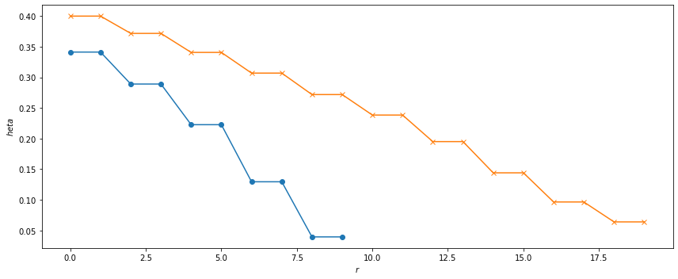

```python
### Figures
fig = plt.figure(figsize=(12,5));
ax1 = fig.add_subplot(1,1,1);
ax1.plot(num1,lam1,marker='o');
ax1.plot(num0,lam0,marker='x');
ax1.set_xlabel("$r$");
ax1.set_ylabel("$\theta$");

fig.tight_layout();
```

```python
sol0 = [];
sol0 = np.append(sol0,1.0);
for i in range(1,dim0):
    sol0 = np.append(sol0,xr0[iter0-1][i]);

sol0 = np.append(sol0,0.0);

#sol

r0 = [];
for i in range(dim0+1):
    r0 = np.append(r0,xi0[i]*xr0[iter0-1][0]**0.5);


sol1 = [];
sol1 = np.append(sol1,1.0);
for i in range(1,dim1):
    sol1 = np.append(sol1,xr1[iter1-1][i]);

sol1 = np.append(sol1,0.0);

#sol

r1 = [];
for i in range(dim1+1):
    r1 = np.append(r1,xi1[i]*xr1[iter1-1][0]**0.5);
```

```python
#sol1
R=np.zeros((dim1,dim0))
R[0][0]=1.0

for i in range(1,dim1):
    R[i][2*i-1]=1.0/4.0
    R[i][2*i  ]=2.0/4.0
    R[i][2*i+1]=1.0/4.0

R
P = 2*R.T

P[0][0]=1.0
R.dot(P)
```

[output not shown]

```python
sola0 = [];
for i in range(0,dim0):
    sola0 = np.append(sola0,xr0[iter0-1][i]);

sola1 = [];
for i in range(0,dim1):
    sola1 = np.append(sola1,xr1[iter1-1][i]);

sola0,sola1
```

[output not shown]

```python
R.dot(sola0),sola1
```

[output not shown]

```python
P.dot(sola1),sola0
```

[output not shown]

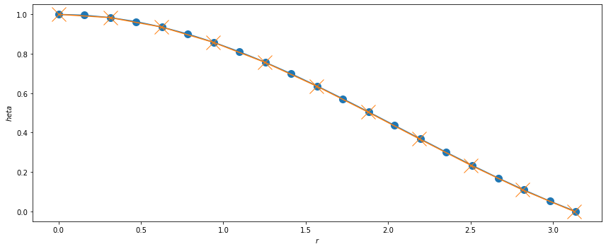

```python
### Figures
fig = plt.figure(figsize=(12,5));
ax1 = fig.add_subplot(1,1,1);
ax1.plot(r0,sol0,markersize=10,marker='o');
ax1.plot(r1,sol1,markersize=20,marker='x');
ax1.set_xlabel("$r$");
ax1.set_ylabel("$\theta$");

fig.tight_layout();
```

```python
### Saving solution during the W4 iteration for figures
solx0 = [];
solp0 = [];
for i in range(iter0+1):
    solx0 = np.append(solx0,xr0[i][0]);
    solp0 = np.append(solp0,pr0[i][0]);

solx1 = [];
solp1 = [];
for i in range(iter1+1):
    solx1 = np.append(solx1,xr1[i][1]);
    solp1 = np.append(solp1,pr1[i][1]);

t1.size,solx1.size
```

[output not shown]

[figure not shown]

```python
### Figures
fig = plt.figure(figsize=(12,5));
ax1 = fig.add_subplot(2,2,1);
ax1.plot(t0,solx0,marker='o');
ax1.set_xlabel("$Iteration$");
ax1.set_ylabel("$x_{0}^{(0)}$");

ax2 = fig.add_subplot(2,2,2);
ax2.plot(t0,solp0,marker='s');
ax2.set_xlabel("$Iteration$");
ax2.set_ylabel("$p_{0}^{(0)}$");


ax3 = fig.add_subplot(2,2,3);
ax3.plot(t1,solx1,marker='d');
ax3.set_xlabel("$Iteration$");
ax3.set_ylabel("$x_{0}^{(1)}$");

ax4 = fig.add_subplot(2,2,4);
ax4.plot(t1,solp1,marker='x');
ax4.set_xlabel("$Iteration$");
ax4.set_ylabel("$p_{0}^{(1)}$");

fig.tight_layout();
```

# Comments on Lane-Emden Solver by W4

## What we can see

- Thanks to the damping effect in the evolution equation in the W4 method, the variables approach the solution.
- If the condition number is quite high, the Python version may not give the correct answer due to the round-off error or the matrix decomposition. (Note that the matrix decomposition in the Python version of the W4 method is different from the FORTRAN90 version in the original paper.)